# McNally_3

Sean McNally

September 27, 2016

#### **1)** Complete problems 10 and 17-18 on pg. 109-111. Use R where possible. Data sets (so you don’t have to type things in) are available at http://www.zoology.ubc.ca/~whitlock/ABD/teaching/datasets.html.

#### Problem 10

##### a. Using an approximate method, provide a rough 95% confidence interval for the population mean 95% CI = 2 * SE

```r
library(magrittr)
library(dplyr)
```

```r
library(ggplot2)
gene_data <- read.csv("04q11NumberGenesRegulated.csv")
head(gene_data)
```

```
##   ngenes frequency
## 1      1        20
## 2      2        10
## 3      3         7
## 4      4         7
## 5      5         8
## 6      6         8
```

```r
mean_gene_data <- gene_data %>%
  summarize(mean_gene_data = mean(ngenes)) %>%
  ungroup ()
sd_gene_data <- gene_data %>%
  summarize(sd_gene_data = sd(ngenes)) %>%
  ungroup ()
head(mean_gene_data)
```

```
##   mean_gene_data
## 1           14.5
```

```r
head(sd_gene_data)
```

```
##   sd_gene_data
## 1     9.343447
```

```r
std_error <- (sd_gene_data)/sqrt(26)
head(std_error)
```

```
##   sd_gene_data
## 1     1.832401
```

```r
CI_95 <- 2 * (std_error)
head(CI_95)
```

```
##   sd_gene_data
## 1     3.664801
```

##### b. Provide an interpretation of the interval you calculated in part (a).

The 95% confidence interval that we calculated in part a allows us to construct a range of values (upper limit and lower limit) in which our calculated populatiom mean falls in. In this case our upper limit of our calculated population mean is

```r
14.5 + 3.66
```

```
## [1] 18.16
```

and our lower limit is

```r
14.5 - 3.66
```

```
## [1] 10.84
```

These values are what allow us to define that we are 95% confident that our estimated parameter will fall between the calculated upper limit and lower limit. In this case our parameter is the population mean.

#### Problem 18

##### *Amorphophallus johnsonii* is a plant growing in West Africa, and its is better known as a “corpse flower.”Its commmon name comes from the fact that when it flowers, it gives off a “powerful aroma of rotting fish and faeces.” The flowes smell this way because their principal pollinators are carrion beetles, who are attracted to such a smell. Beath (1996) observed the number of carrion beetles(*Phaeochrous amplus*) that arrive per night to flowers of this species. The data are as follows:

51, 45, 61, 76, 11, 117, 7, 132, 52, 149

##### a What is the mean and standard deviation of beetles per flower?

```r
corpse_beetles <- c(51, 45, 61, 76, 11, 117, 7, 132, 52, 149 )
mean(corpse_beetles)
```

```
## [1] 70.1
```

```r
sd(corpse_beetles)
```

```
## [1] 48.50074
```

##### b What is the standard error of this estimate of the mean

```r
std_error_corpse_beetles <- (48.50)/sqrt(10)
head(std_error_corpse_beetles)
```

```
## [1] 15.33705
```

##### c Give an approximate 95% confidence interval of the mean. Provide lower and upper limits.

```r
CI_95_beetles <- 2 * 15.34
head(CI_95_beetles)
```

```
## [1] 30.68
```

Upper limit

```r
70.1 + 30.68
```

```
## [1] 100.78
```

Lower limit

```r
70.1 - 30.68
```

```
## [1] 39.42
```

**2)** The other day, [Dave Curran](https://twitter.com/iamreddave) using some of the code from our lab made a wonderful animation of change in arctic sea ice.

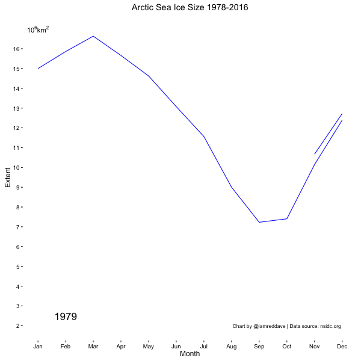

He used data from

ftp://sidads.colorado.edu/DATASETS/NOAA/G02135/north/daily/data/NH_seaice_extent_final_v2.csv ftp://sidads.colorado.edu/DATASETS/NOAA/G02135/north/daily/data/NH_seaice_extent_nrt_v2.csv

I’m providing you with a cleaned form of his data (his code is [here](https://gist.github.com/cavedave/c5c2224c8c38661236c1c1ce894fd28f)) for you to work with in a few plots. The data file is called `NH_seaice_extent_monthly_1978_2016.csv`

**2.1)** Load the data using `readr` and make the `Month_Names` column into a factor whose levels are in order of month.

```r
library(readr)
library(dplyr)
library(forcats)
library(ggplot2)
sea_ice <- read.csv("~/Desktop/BIOL 607/Homework/homework_3_fork/data/NH_seaice_extent_monthly_1978_2016.csv")
sea_ice_sorted <- sea_ice %>%
mutate(Month_Name = factor(Month_Name, levels = month.abb))
sort(sea_ice_sorted$Month_Name)
```

[output not shown]

```r
levels(sea_ice_sorted$Month_Name)
```

```
##  [1] "Jan" "Feb" "Mar" "Apr" "May" "Jun" "Jul" "Aug" "Sep" "Oct" "Nov"
## [12] "Dec"
```

**2.2)** Make a boxplot showing the variability in sea ice extent every month.

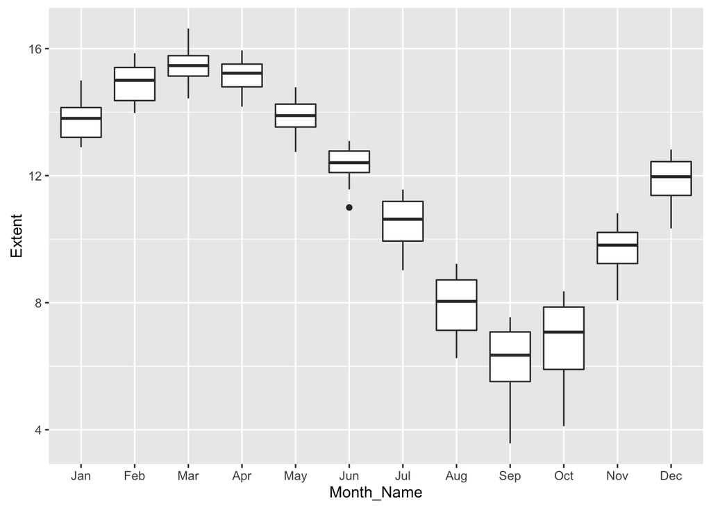

```r
box_ice <- ggplot(data = sea_ice_sorted, mapping = aes(x = Month_Name, y = Extent))
box_ice +
  geom_boxplot()
```

**2.3)** Use `dplyr` to get the annual minimum sea ice. Plot minimum ice by year, and add a trendline (either a smooth spline or a straight line).

```r
min_sea_ice <- sea_ice_sorted %>%
  group_by(Year) %>%
  mutate(min_ice = min(Extent)) %>%
  ungroup()
head(min_sea_ice)
```

```
## # A tibble: 6 × 7
##    Year Month   Day Extent Missing Month_Name min_ice
##   <int> <int> <int>  <dbl>   <int>     <fctr>   <dbl>
## 1  1978    11     1 10.670       0        Nov  10.670
## 2  1978    12     1 12.725       0        Dec  10.670
## 3  1979     2     1 15.857       0        Feb   7.228
## 4  1979     3     1 16.635       0        Mar   7.228
## 5  1979     6     1 13.076       0        Jun   7.228
## 6  1979     7     1 11.562       0        Jul   7.228
```

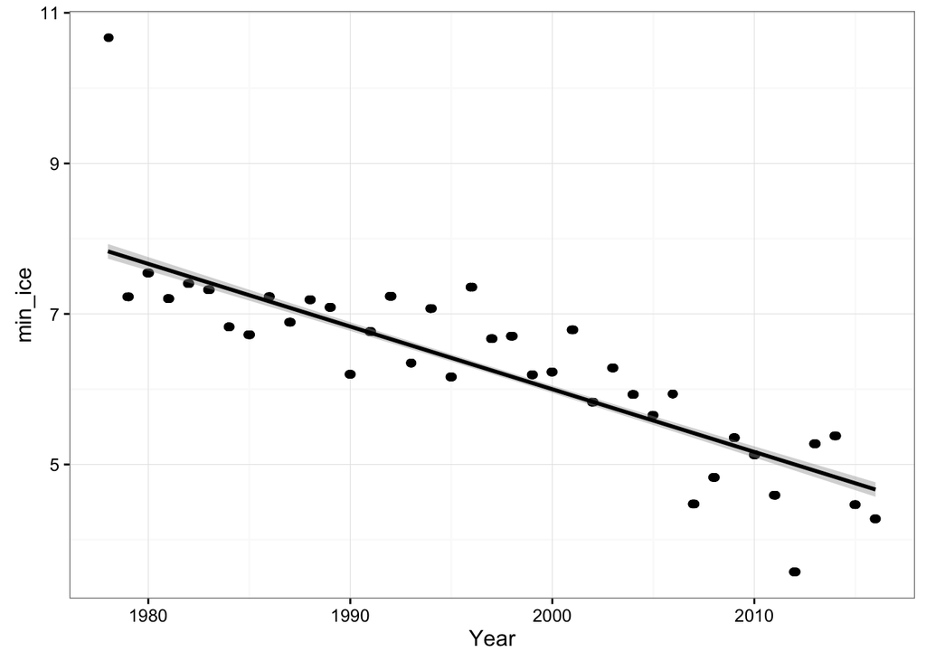

```r
min_sea_ice_plot <- ggplot(data = min_sea_ice, mapping = aes(x = Year, y = min_ice))
min_sea_ice_plot + geom_jitter(width = 0.2, height = 0) +
  stat_smooth(method = "lm", color = "black" ) +
  theme_bw()
```

**2.4)** Plot sea ice by year, with different lines for different months. Then, add a new column (`mutate`!) using the ggplot2 function `cut_interval(Month, n=4)` - this will create four even bins. Seasons, if you will. Use `facet_wrap` on the same plot and split the plot into seasons.

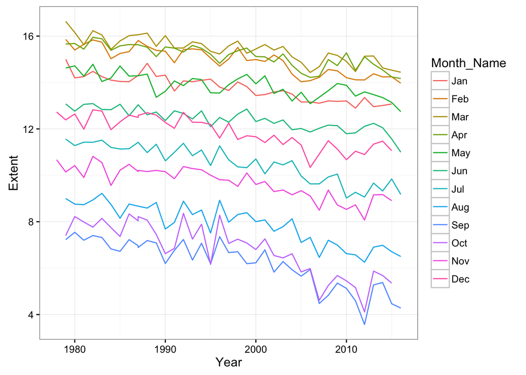

```r
library(RColorBrewer)
sea_ice_year <- ggplot(data = sea_ice_sorted, mapping = aes(x = Year, y = Extent))
sea_ice_year + geom_line(mapping = aes(group = Month_Name, x = Year, y = Extent, color = Month_Name)) +
  theme_bw()
```

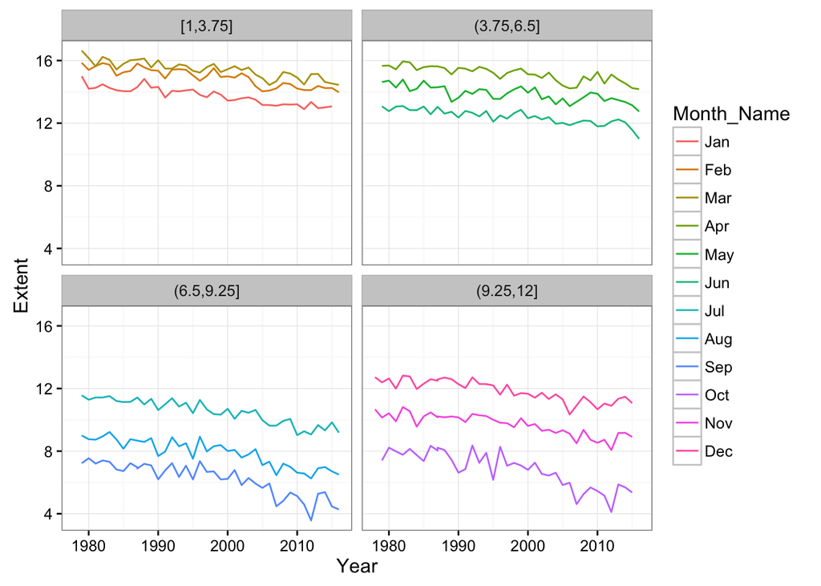

```r
seasonal_sea_ice <- sea_ice_sorted %>%
  mutate(season = cut_interval(Month,n = 4))
help("facet_wrap")
ggplot(seasonal_sea_ice) +
  geom_line(mapping = aes(group = Month_Name, x = Year, y =Extent, color = Month_Name)) +
  facet_wrap(~season) +
  theme_bw()
```

**2.5)** Last, make a line plot of sea ice by month. Gussy it up with colors by year, a different theme, and whatever other annotations, changes to axes, etc., you think best show the story of this data.

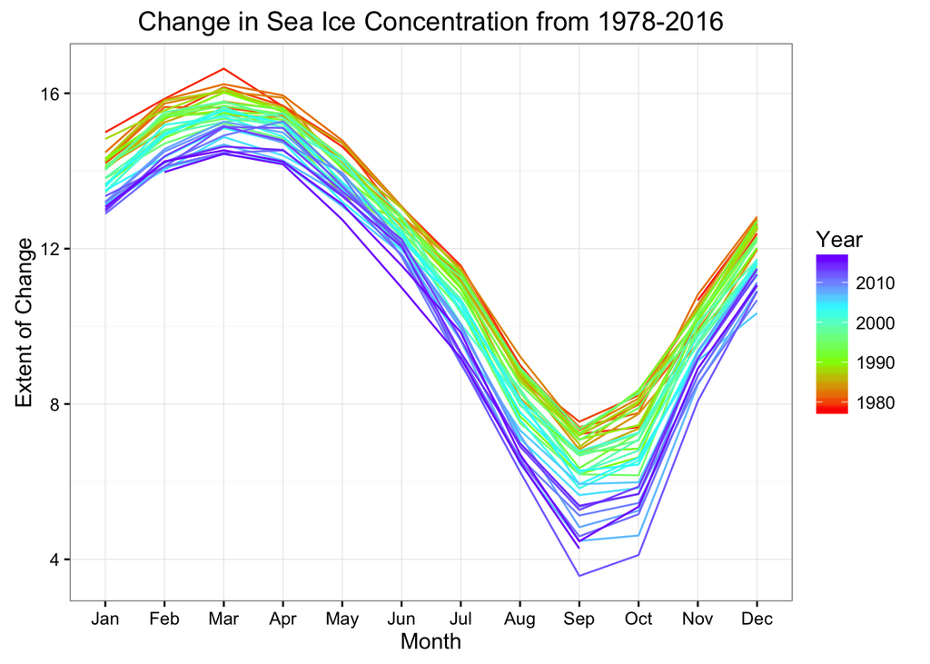

```r
library(ggplot2)
library(ggthemes)
library(ggThemeAssist)
ggplot(data = sea_ice_sorted, mapping = aes(x = Month_Name, y = Extent, frame = Year)) +
  geom_line(mapping = aes(x = Month_Name, y = Extent, group = Year, color = Year)) +
  theme_bw() +
  labs(title = "Change in Sea Ice Concentration from 1978-2016", x = "Month", y = "Extent of Change") +
  scale_colour_gradientn(colours=rainbow(4))
```

**2.6 Extra Credit)** Make it animated. ughhhhhhhh